# aIc: am I compositional?

Greg Gloor

05 July, 2022

#### Abstract

Document summary

#### Package

aIc 0.1.1

# 1 A simple test function to determine if the data have typical compositional data pathologies or are pathological in some other way.

The overall idea here is that pathologies in data have knock-on effects for analysis and one should be aware of this prior to starting an analysis. In the context of high throughput sequencing, the same library can be sequenced on instruments that give vastly different numbers of output reads (from 1M to $\ge$ 2B reads). Thus, three important properties should be scale invariance, perturbation invariance, and sub-compositional dominance.

One additional complication is the number and distribution of 0 values in the dataset. This depends on the makeup of the original samples, and on the sequencing depth. If the groups of samples have different background distributions (say different sets of genes expressed in each group, or different bacterial species in each group), then there will be asymmetric 0 distribution. If the samples are sequenced too shallowly, then features with low values will drop out and be represented as 0 values. If an asymmetric dataset is sequenced shallowly, then both pathologies will occur. The effect of adjusting the compositional basis (denominator) of the datasets can be explored using the iqlr and lvha approaches that attempt to identify unvarying denominators.

These, and others, are outlined below.

## 1.1 List of common data pathologies:

   Lovell et al. (2015) https://doi.org/10.1371/journal.pcbi.1004075, Quinn et al. (2017) https://doi.org/10.1038/s41598-017-16520-0, Egozcue et al. https://doi.org/10.17713/ajs.v47i1.689
3. Sub-compositional distance dominance: This property means that any feature subset of the data should have smaller distances between samples than the full dataset (or any superset of the subset). This property should be met by any compositionally appropriate transform which converts features to be linearly different (as the centred log-ratio transform does).
4. Scale invariance: This property means that changing the scale of the data — multiplying or dividing by and arbitrary value — should have no or only a minimal effect on the distances between samples.
5. Perturbation invariance: This property means that simple perturbations of the data or a subset of the data should have minimal effects on the outcome. In particular, should have minimal effects on distances between samples. This is because in a composition, a perturbation, a multiplicative change in the feature, simply moves the dataset from one place to another in the sample space.

The selex dataset is a favourite of mine to use because we have a standard of truth, and because it behaves so badly with so many tools. It is included as the test dataset in the ALDEx2 R package and can be accessed there.

McMurrough et al (2018) https://doi.org/10.1093/nar/gky976

Fernandes et al (2014) https://doi.org/10.1186/2049-2618-2-15

# 2 Sub-compositions and correlation (coherence)

The first test is for correlation in a full dataset and a subset of the data and if different the data are compostions and need to be treated as such. This is a correlation coherence test. Correlations in compositional data are not stable to subsetting and any transformation that is not coherent should not be trusted to build correlation networks unless one is using compositionally appropriate methods.

As a simple example, let’s try the selex dataset with the clr and log of the edgeR TMM transformation. Here the expected result is that the features are not sub-compostionally coherent under the test as shown by Lovell in 2015.

In other words, correlations change as different filtering and pre-processing steps are performed on the data. If this happens in your data with your transformation do not use correlation, and use a compositionally appropriate measure of association.

```r
test.cor.clr <- aIc.coherent(selex, group=group, zero.method='prior',
  norm.method='clr', log=F, denom='all')
```

```
## computing center with all features
## computing center with all features
```

```r
test.cor.TMM <- aIc.coherent(selex, group=group, zero.method='prior',
  norm.method='TMM', log=T)
test.cor.clr$is.coherent
```

```
## [1] "No"
```

```r
test.cor.TMM$is.coherent
```

```
## [1] "No"
```

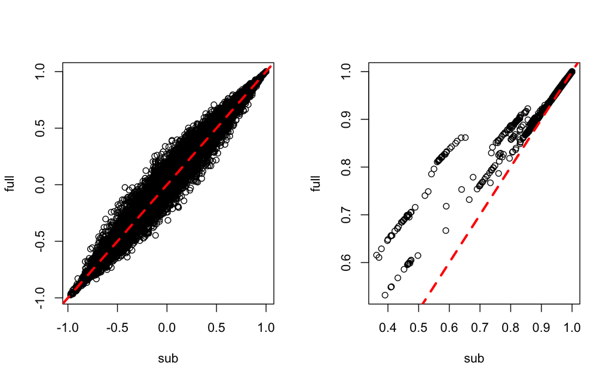

```r
par(mfrow=c(1,2))
plot(test.cor.clr$plot)
abline(0,1, col='red', lty=2, lwd=3)
plot(test.cor.TMM$plot)
abline(0,1, col='red', lty=2, lwd=3)
```

Thus, we see that under the clr and TMM, features in common between sub-compositions and the full composition display variable correlations.

# 3 Sub-compositions and distance (dominance)

The second test is sub-compositional dominance. That is, the subset should always have an equal or smaller difference between samples than the full (non-subsetted) dataset. We will use the same dataset and transforms.

```r
test.dom.clr <- aIc.dominant(selex, group=group, zero.method='prior',
  norm.method='clr', log=F, denom='all')
```

```
## computing center with all features
## computing center with all features
```

```r
test.dom.TMM <- aIc.dominant(selex, group=group, zero.method='prior',
  norm.method='TMM', log=T)
test.dom.clr$is.dominant
```

```
## [1] "Yes"
```

```r
test.dom.TMM$is.dominant
```

```
## [1] "Yes"
```

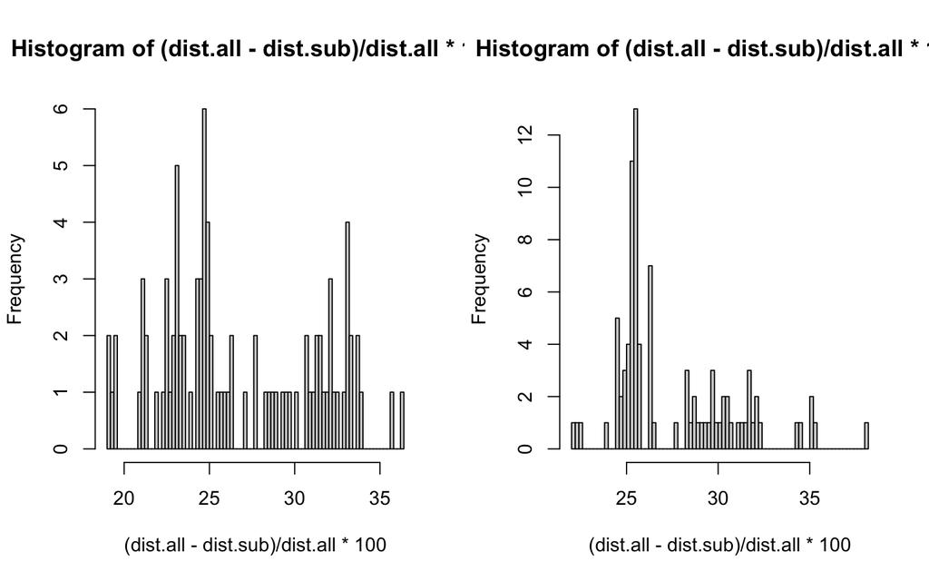

```r
par(mfrow=c(1,2))
plot(test.dom.clr$plot)
abline(v=0, col='red', lty=2, lwd=3)
plot(test.dom.TMM$plot)
abline(v=0, col='red', lty=2, lwd=3)
```

Here both transforms are distance dominant and the x-axis is the proportion of divergenece from the distances in the full composition. Note however the large and bimodal distance dominant property of the log(TMM) transformation.

# 4 Testing for scale invariance

The third test is scale invariance. That is, the data should have the same distance between samples when the scale (sequencing depth) changes. We will use the same dataset and transforms

```r
test.scale.clr <- aIc.scale(selex, group=group, zero.method='GBM',
  norm.method='clr', log=F, denom='gbm')
```

```
## denom: 'gbm' unrecognized. Using all features.
## denom: 'gbm' unrecognized. Using all features.
```

```r
test.scale.TMM <- aIc.scale(selex, group=group, zero.method='GBM',
  norm.method='TMM', log=T)
test.scale.clr$is.scale
```

```
## [1] "Yes"
```

```r
test.scale.TMM$is.scale
```

```
## [1] "Yes"
```

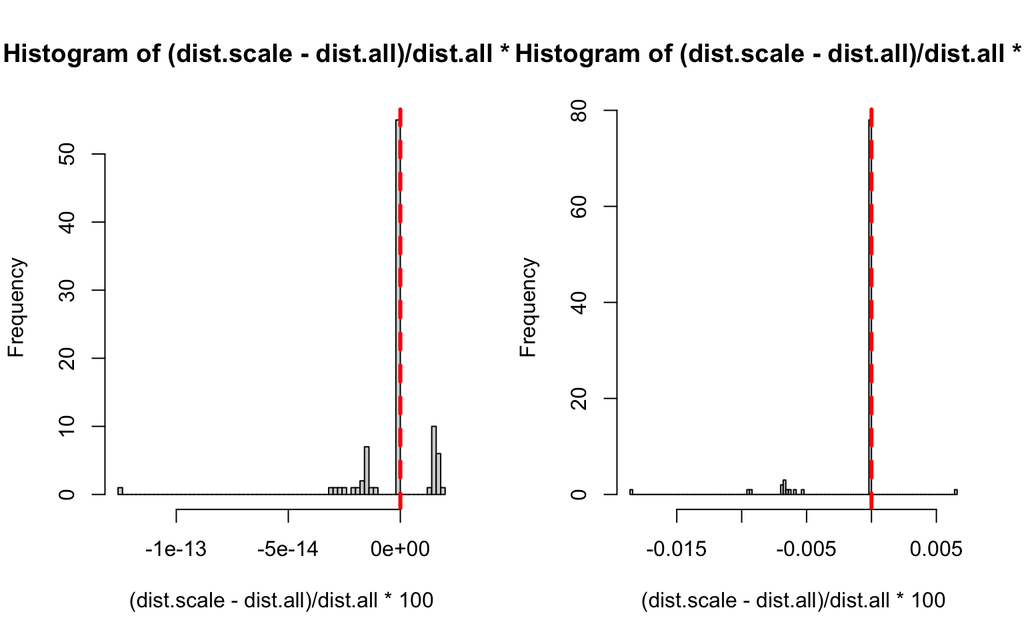

```r
par(mfrow=c(1,2))
plot(test.scale.clr$plot)
abline(v=0, col='red', lty=2, lwd=3)
plot(test.scale.TMM$plot)
abline(v=0, col='red', lty=2, lwd=3)
```

# 5 Testing for perturbation invariance

The fourth test is perturbation invariance. That is, the data should have the same distance between samples when one or a few of the features have some perturbation. In the context of a HTS experiment, this could correspond to a systematic difference between feature capture or feature sequencing probability for a subset of the features.

```r
test.perturb.clr <- aIc.perturb(selex, group=group, zero.method='prior',
  norm.method='clr', log=F, denom='all')
```

```
## computing center with all features
## computing center with all features
```

```r
test.perturb.TMM <- aIc.perturb(selex, group=group, zero.method='prior',
  norm.method='TMM', log=T)
test.perturb.clr$is.perturb
```

```
## [1] "Yes"
```

```r
test.perturb.TMM$is.perturb
```

```
## [1] "No"
```

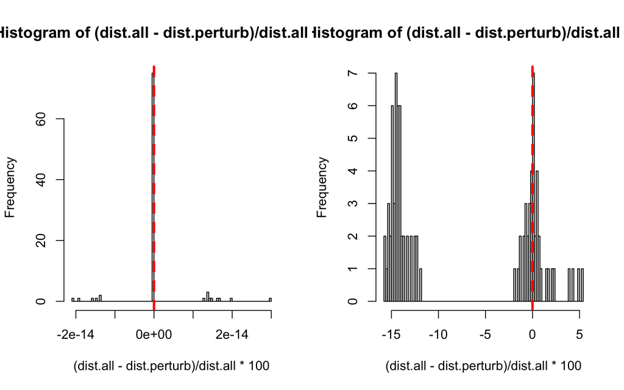

```r
par(mfrow=c(1,2))
plot(test.perturb.clr$plot)
abline(v=0, col='red', lty=2, lwd=3)
plot(test.perturb.TMM$plot)
abline(v=0, col='red', lty=2, lwd=3)
```

# 6 Conclusion

I hope you can see that data pathologies can have real world implications for your analysis.

The failure of sub-compositional coherence means that any network analysis that is done using anything other than a compositionally appropriate measure is doomed to failure if and when the data are cleaned or otherwise manipulated.

Distance dominance, scale invariance and perturbation invariance have obvious implications for dimension reduction and clustering. In all cases, the clr was preferred over the log(TMM) normalization and this one part of the ALDEx2 secret sauce as a generally useful tool.